# CISER Statistics in R Workshop: Day 2

Presented by the Center for Interdisciplinary Statistical Education and Research

# Workshop Overview

- Day 1
  - Sample Size Calculations
  - Using R Data Frames
  - t-tests
- Day 2
  - Linear regression
  - Full/reduced drop tests
  - Testing linear model assumptions
  - Reading data into R
  - Tests and models for binary data

# Motor Trend Car Road Tests

The data was extracted from the 1974 Motor Trend US magazine, and comprises fuel consumption and 10 aspects of automobile design and performance for 32 automobiles (1973–74 models).

- mpg Miles/(US) gallon
- wt Weight (1000 lbs)
- am Transmission (0 = automatic, 1 = manual)
- gear Number of forward gears

```r
head(mtcars)
```

```
##                    mpg cyl disp  hp drat    wt  qsec vs am gear carb
## Mazda RX4         21.0   6  160 110 3.90 2.620 16.46  0  1    4    4
## Mazda RX4 Wag     21.0   6  160 110 3.90 2.875 17.02  0  1    4    4
## Datsun 710        22.8   4  108  93 3.85 2.320 18.61  1  1    4    1
## Hornet 4 Drive    21.4   6  258 110 3.08 3.215 19.44  1  0    3    1
## Hornet Sportabout 18.7   8  360 175 3.15 3.440 17.02  0  0    3    2
## Valiant           18.1   6  225 105 2.76 3.460 20.22  1  0    3    1
```

# Simple Linear Regression in R

- We can use the `mtcars` data to get a sense of the relationship between a car’s weight and it’s gas mileage
- The `plot` function can be used to create a scatter plot for continuous data

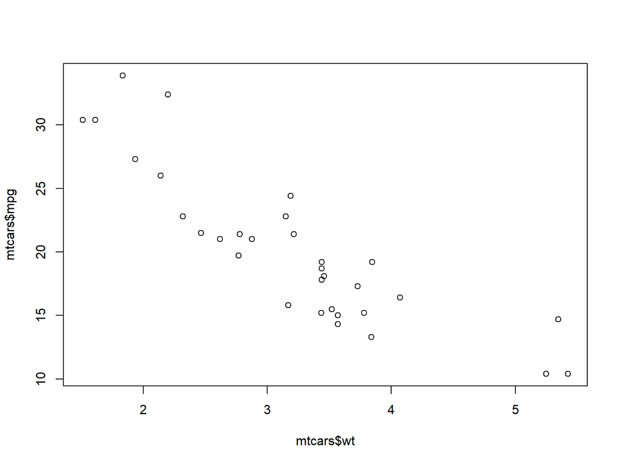

```r
plot(mtcars$wt, mtcars$mpg)
```

- The plot appears to show a relationship between the weight of a car and the gas mileage

# Exercise 1: Construct a scatter plot

# Exercise 1: Solution

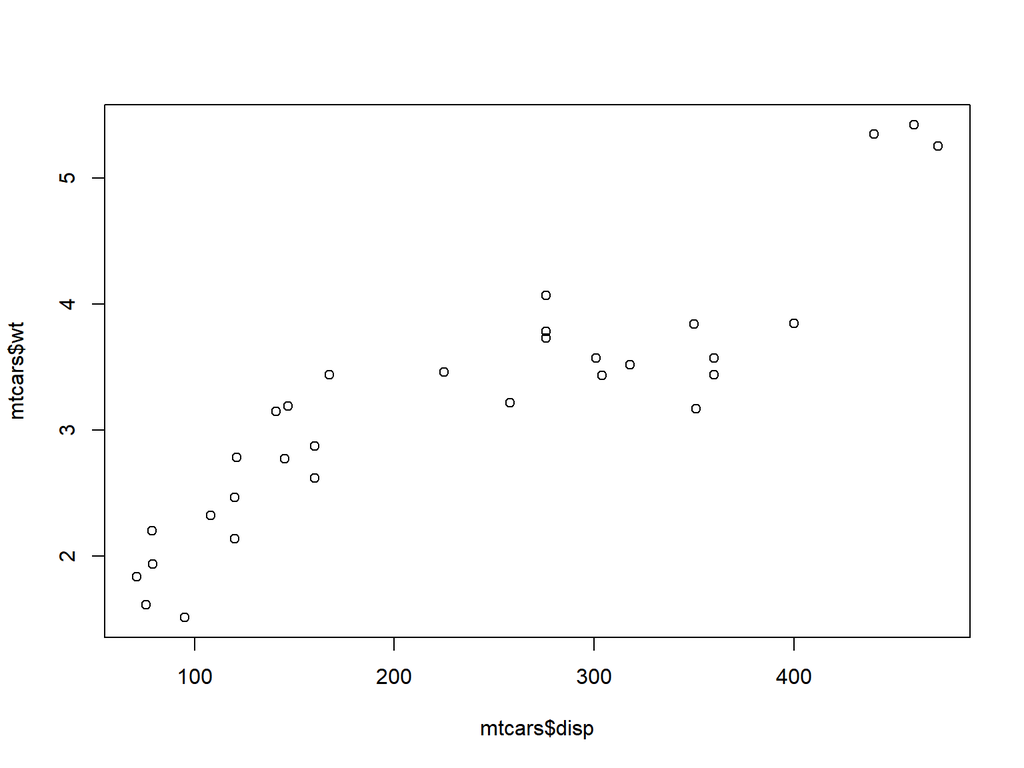

```r
plot(mtcars$disp, mtcars$wt)
```

# Linear regression to understand the relationship between gas mileage and weight

- We can use linear regression to model this data
- The function `lm` will fit a linear regression

```r
mod <- lm(mpg ~ wt, data = mtcars)
```

- The expression `mpg ~ wt` is known as a model formula, and is a key aspect of fitting various models in R
- The model formula can be read as: *mpg is modeled as a (linear) function of weight*
- We can look at a simple summary of the linear regression by typing

```r
summary(mod)
```

```
##
## Call:
## lm(formula = mpg ~ wt, data = mtcars)
##
## Residuals:
##     Min      1Q  Median      3Q     Max
## -4.5432 -2.3647 -0.1252  1.4096  6.8727
##
## Coefficients:
##             Estimate Std. Error t value Pr(>|t|)
## (Intercept)  37.2851     1.8776  19.858  < 2e-16 ***
## wt           -5.3445     0.5591  -9.559 1.29e-10 ***
## ---
## Signif. codes:  0 '***' 0.001 '**' 0.01 '*' 0.05 '.' 0.1 ' ' 1
##
## Residual standard error: 3.046 on 30 degrees of freedom
## Multiple R-squared:  0.7528, Adjusted R-squared:  0.7446
## F-statistic: 91.38 on 1 and 30 DF,  p-value: 1.294e-10
```

- Key metrics to look at are:
  - Parameter estimates (intercept and slope)
  - Standard error in the estimates
  - t-statistic for testing the hypothesis that each parameter is equal to zero
  - Adjusted R-squared indicates the expected out of sample variance explained for the same population
  - Overall test of significance for all parameters in the model except the intercept

# Exercise 2: Fitting a linear model

- Fit a linear model of gross horsepower (hp) vs. displacement
- Compare this fit to a fit of gross horsepower (hp) vs. number of cylinders
- Compare the R-squared adjusted to get a sense of which variable better explains horsepower

# Exercise 2: Solution

- The R-squared adjusted for the model with displacement is 0.61
- The R-squared adjusted for the model with cyl is 0.68
- The R-squared adjusted is larger for the model with cyl

```r
mod <- lm(hp ~ disp, data = mtcars)
summary(mod)$adj.r.squared
```

```
## [1] 0.6131197
```

```r
mod <- lm(hp ~ cyl, data = mtcars)
summary(mod)$adj.r.squared
```

```
## [1] 0.6827344
```

# Extracting Statistics from a Fitted Regression Model

- A fitted regression model comes with various statistics
- Depending on the type of regression model, there may be different statistics available
- You can check what is available by looking at the `value` section in the help for the function that has been called
- Alternatively, you can look at the names of the list that was returned

```r
mod <- lm(hp ~ cyl, data = mtcars)
names(summary(mod))
```

```
##  [1] "call"          "terms"         "residuals"     "coefficients"
##  [5] "aliased"       "sigma"         "df"            "r.squared"
##  [9] "adj.r.squared" "fstatistic"    "cov.unscaled"
```

```r
summary(mod)$adj.r.squared
```

```
## [1] 0.6827344
```

# Fitting Models with Factor Variables

- Lets consider how the mpg relates to the number of forward gears
- For this dataset, there are cars with 3, 4, and 5 total forward gears
- We could treat gears as a continuous variable and fit a linear model
- Below is a plot showing mpg vs. gear along with the best fit linear regression model with gear treated as a linear continuous predictor

```r
mod <- lm(mpg ~ gear, data = mtcars)
summary(mod)$adj.r.squared
```

```
## [1] 0.2050292
```

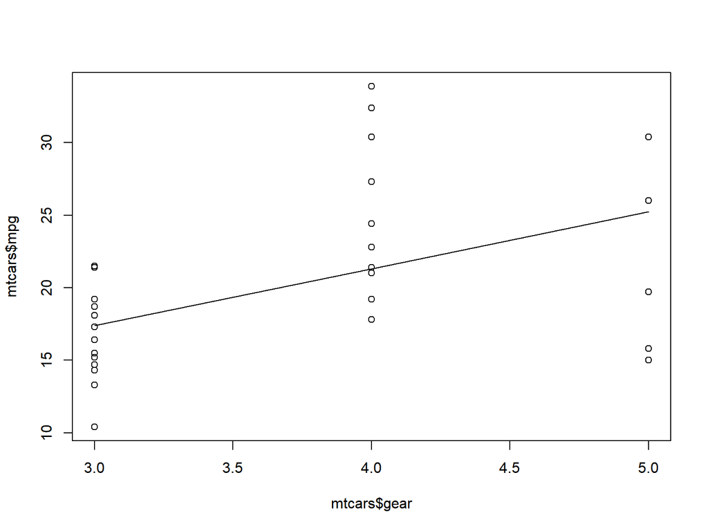

```r
plot(mtcars$gear, mtcars$mpg)
lines(mtcars$gear, fitted(mod))
```

- Assuming linearity of gear does not seem to adequately reflect the relationship between the number of gears and the gas mileage

# Fitting Models with Factor Variables

- We can treat gear as a factor variable
- We can include the factor function directly in the model formula

```r
mtcars$fgear <- factor(mtcars$gear)
mod <- lm(mpg ~ fgear, data = mtcars)
summary(mod)$adj.r.squared
```

```
## [1] 0.3897811
```

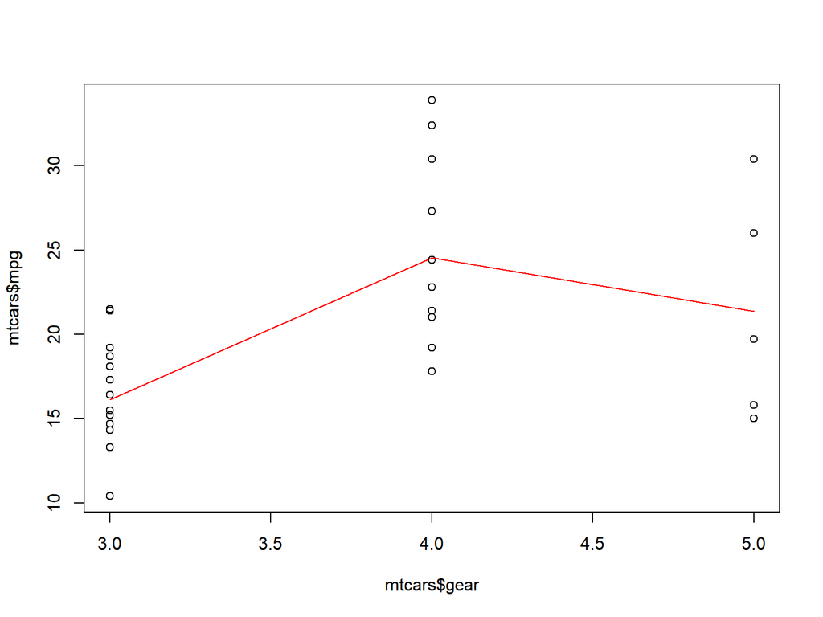

```r
plot(mtcars$gear, mtcars$mpg)
lines(mtcars$gear, fitted(mod))
lines(mtcars$gear, fitted(mod), col = "red")
```

- Treating gear as a categorical variable allows for more flexibility in the relationship
- The R-squared adjusted for mpg~factor(gear) is 0.39
- The R-squared adjusted for mpg~gear is 0.21

# Multiple Regression with Interactions

- We can construct multiple regression models by including more variables in the model
- If we are interested in making a model that best explains the variation in gas mileage, we might try something like

```r
mod <- lm(mpg ~ fgear + wt + carb + wt:carb, data = mtcars)
```

- In this model, we have included linear terms for wt, fgear, carb and an interaction between wt and carb
- Model terms (wt, fgear, carb, wt:carb) are included additively using the `+` operator
- Interaction terms can be created using the `:` operator
- This model formula can be simplified by instead using the `*` operator
- The `*` operator includes the interaction and all lower order terms

```r
mod <- lm(mpg ~ fgear + wt*carb, data = mtcars)
summary(mod)$adj.r.squared
```

```
## [1] 0.8421264
```

# Exercise 3: Fit a multiple regression model

# Exercise 3: Solution

- There appears to be substantial evidence against the null hypothesis of no interaction between displacement and whether the car is automatic/manual (t = 3.85, df = 28, p = 0.0006).

```r
mod <- lm(hp ~ disp + am + disp:am, data = mtcars)
summary(mod)
```

```
##
## Call:
## lm(formula = hp ~ disp + am + disp:am, data = mtcars)
##
## Residuals:
##     Min      1Q  Median      3Q     Max
## -47.648 -23.298  -3.232  16.068  67.889
##
## Coefficients:
##             Estimate Std. Error t value Pr(>|t|)
## (Intercept)  41.7170    21.0504   1.982 0.057400 .
## disp          0.4083     0.0680   6.003 1.81e-06 ***
## am          -42.7202    27.3668  -1.561 0.129751
## disp:am       0.4825     0.1253   3.851 0.000625 ***
## ---
## Signif. codes:  0 '***' 0.001 '**' 0.01 '*' 0.05 '.' 0.1 ' ' 1
##
## Residual standard error: 31.79 on 28 degrees of freedom
## Multiple R-squared:  0.8059, Adjusted R-squared:  0.7851
## F-statistic: 38.74 on 3 and 28 DF,  p-value: 4.235e-10
```

# Full / Reduced Drop Tests for Testing Categorical Variables

```r
mod <- lm(mpg ~ wt + fgear, data = mtcars)
summary(mod)
```

```
##
## Call:
## lm(formula = mpg ~ wt + fgear, data = mtcars)
##
## Residuals:
##    Min     1Q Median     3Q    Max
## -3.517 -2.358 -0.355  1.850  5.821
##
## Coefficients:
##             Estimate Std. Error t value Pr(>|t|)
## (Intercept)  35.2156     2.8690  12.274 8.72e-13 ***
## wt           -4.9090     0.7112  -6.902 1.68e-07 ***
## fgear4        2.1631     1.4485   1.493    0.147
## fgear5       -0.9121     1.7519  -0.521    0.607
## ---
## Signif. codes:  0 '***' 0.001 '**' 0.01 '*' 0.05 '.' 0.1 ' ' 1
##
## Residual standard error: 2.915 on 28 degrees of freedom
## Multiple R-squared:  0.7887, Adjusted R-squared:  0.766
## F-statistic: 34.83 on 3 and 28 DF,  p-value: 1.375e-09
```

- `summary` does not provide overall evidence concerning a `gear` effect
- We can drop terms and summarise the evidence by comparing full and reduced models

```r
mod0 <- lm(mpg ~ wt, data = mtcars)
anova(mod, mod0)
```

```
## Analysis of Variance Table
##
## Model 1: mpg ~ wt + fgear
## Model 2: mpg ~ wt
##   Res.Df    RSS Df Sum of Sq      F Pr(>F)
## 1     28 237.95
## 2     30 278.32 -2   -40.372 2.3753 0.1115
```

- This will provide us with a p-value that summarises the effect of `fgear` conditional on `wt` being in the model
- We can obtain on test for each term in the model using the `drop1` command

```r
drop1(mod, test = "F")
```

```
## Single term deletions
##
## Model:
## mpg ~ wt + fgear
##        Df Sum of Sq    RSS     AIC F value    Pr(>F)
## <none>              237.95  72.202
## wt      1    404.85 642.80 102.003 47.6398 1.677e-07 ***
## fgear   2     40.37 278.32  73.217  2.3753    0.1115
## ---
## Signif. codes:  0 '***' 0.001 '**' 0.01 '*' 0.05 '.' 0.1 ' ' 1
```

# Exercise 4: Test multiple categorical variables

- Using the `mtcars` data, fit a model with `mpg` as the response, and `cyl` and `gear` as **categorical** explanatory variables
- Obtain F drop test statistics for each of the two factors (cyl, gear) conditional on the other being in the model

# Exercise 4: Solution

```r
mtcars$fcyl <- factor(mtcars$cyl)
drop1(lm(mpg ~ fgear + fcyl, data = mtcars))
```

```
## Single term deletions
##
## Model:
## mpg ~ fgear + fcyl
##        Df Sum of Sq    RSS     AIC
## <none>              293.01  80.863
## fgear   2      8.25 301.26  77.752
## fcyl    2    349.79 642.80 102.003
```

# Testing Assumptions of the Linear Model

- Key assumptions
  - Linearity of y vs. x
  - Equal variance for all errors
  - Normality
  - Independence
- Testing linearity
  - Plot residuals vs. each x
- Testing equal variance
  - Plot residuals vs. fitted values
- Testing normality
  - Normal quantile plot
- Testing independence
  - Consider design
  - Consider plotting over space/time

# Testing Assumptions: Kentucky Derby

- Kentucky Derby horse race winners from 1896 to 2011 is available from the package Sleuth3
- In all those years the race was 1.25 miles in length so that winning time and speed are exactly inversely related.
- Important variables are:
  - Speed
  - Conditions (Fast/Slow track)
  - Starters (# horses in the race)
  - Year

```r
library(Sleuth3)
derby <- ex0920
head(derby)
```

```
##   Year        Winner Starters NetToWinner   Time Speed Track Conditions
## 1 1896     Ben Brush        8        4850 127.75 35.23 Dusty       Fast
## 2 1897    Typhoon II        6        4850 132.50 33.96 Heavy       Slow
## 3 1898       Plaudit        4        4850 129.00 34.88  Good       Fast
## 4 1899        Manuel        5        4850 132.00 34.09  Fast       Fast
## 5 1900 Lieut. Gibson        7        4850 126.25 35.64  Fast       Fast
## 6 1901  His Eminence        5        4850 127.75 35.23  Fast       Fast
```

- We consider fitting a linear regression model for Speed vs. Year

```r
mod <- lm(Speed ~ Year, data = derby)
```

# Testing Assumption of Linearity: Kentucky Derby

- We can test the assumption of linearity of Year by plotting the model residuals against the Year
- The `residuals` function can be used to extract the residuals from the model
- It is similar to just using `mod$residuals`, but allows you to compute specialized residuals if desired

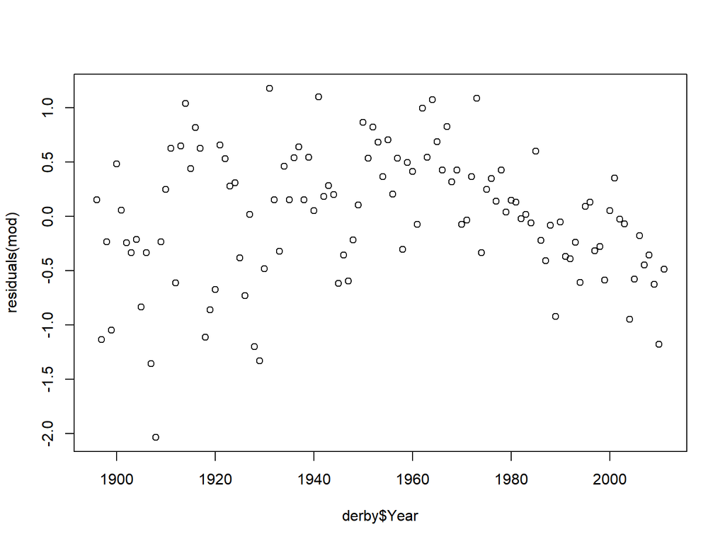

```r
plot(derby$Year, residuals(mod))
```

- Trends in the residuals indicate that we may not have captured the relationship between Year and the response
- We can try including a quadratic term
- Note that `^2` indicates something special for model formulas - to include all second order interactions and lower terms
- The use of the `I` function allows us to compute Year^2 before we evaluate the model formula

```r
mod <- lm(Speed ~ Year + I(Year^2), data = derby)
```

- The new model seems to adequately capture the relationship between Speed and Year

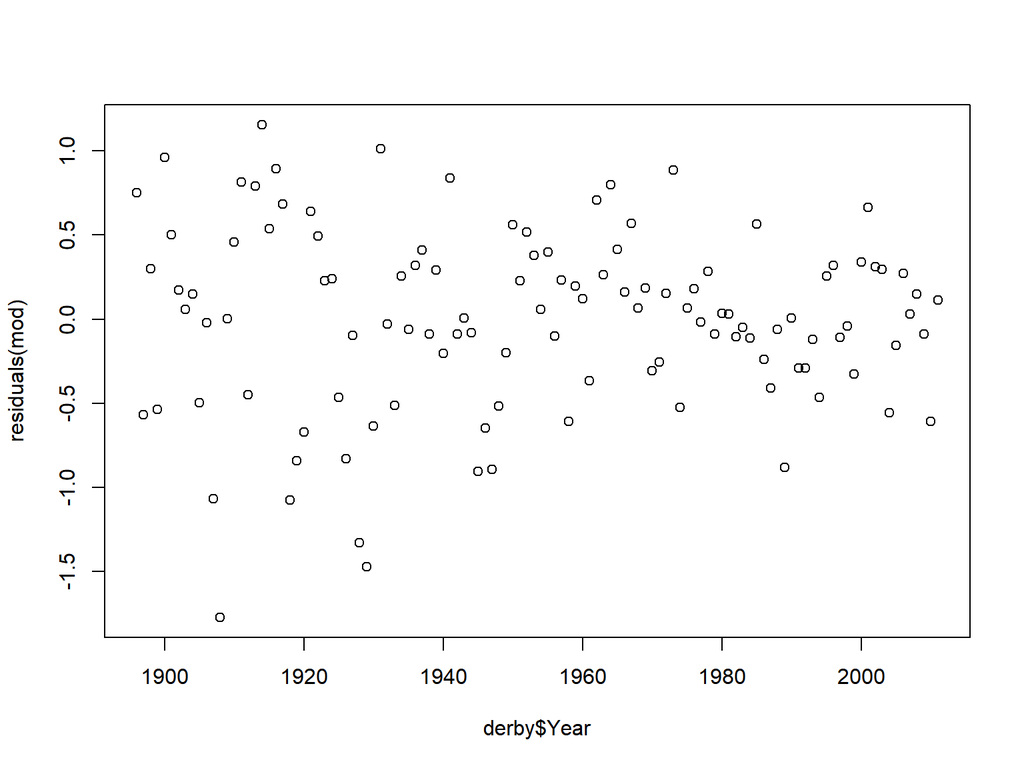

```r
plot(derby$Year, residuals(mod))
```

# Testing Assumption of Normality: Kentucky Derby

- A normal quantile plot can be conducted to look for evidence against the assumption of normality of the errors
- Note that normality is not a critical assumption, minor to moderate deviations from normality are not likely to have a substantial effect on p-values / confidence intervals
- We are looking typically for major deviations

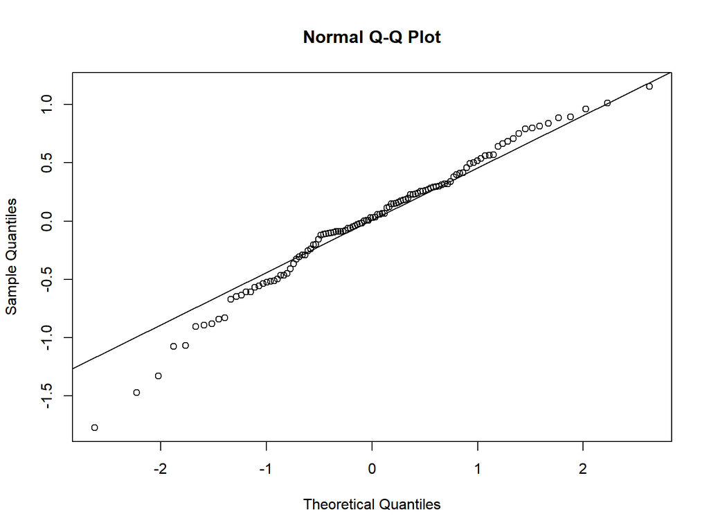

```r
qqnorm(residuals(mod))
qqline(residuals(mod), probs = c(0.25, 0.75))
```

# Testing Assumption of Variance Homogeneity

- The plausibility of the variance homogeneity can be assessed with a plot of residuals vs. fitted values

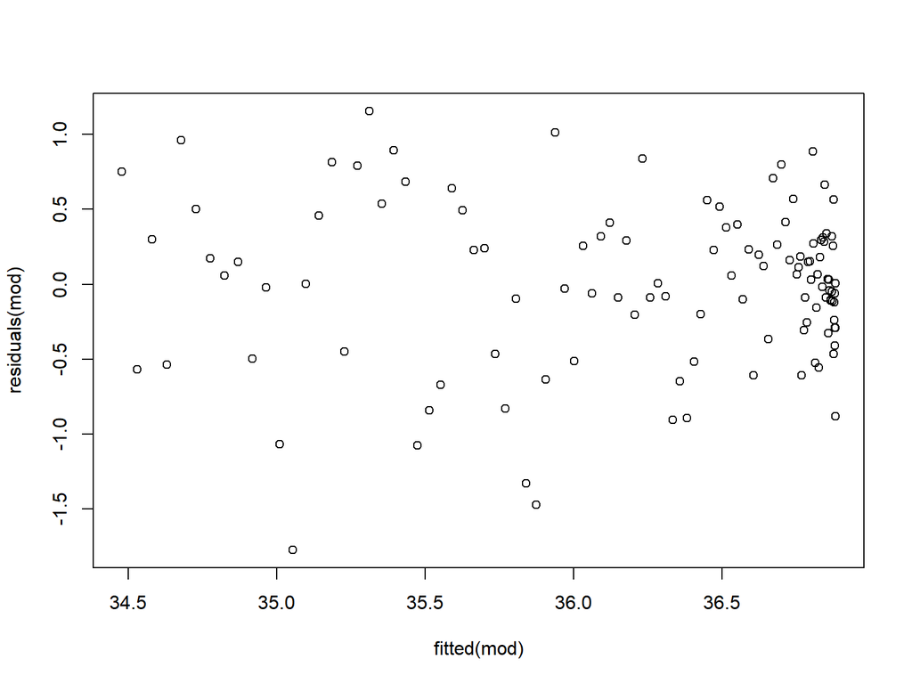

```r
plot(fitted(mod), residuals(mod))
```

- Overall, we are looking for moderate changes in the spread of the data for different fitted values
- This model fitted here does not appear to have any major issues with variance homogeneity

# Exercise 5: Testing Assumptions

- Use the mtcars dataset
- Consider the variables `mpg`, `disp`, `am`
- Model `mpg` as a function of `disp` and `am`
- Test the assumption of linearity of `disp` by plotting residuals vs. disp
- Test the assumption of normality of the errors by using `qqnorm`
- Test the assumption of variance homogeneity by plotting residuals vs. fitted values

# Exercise 5: Solution

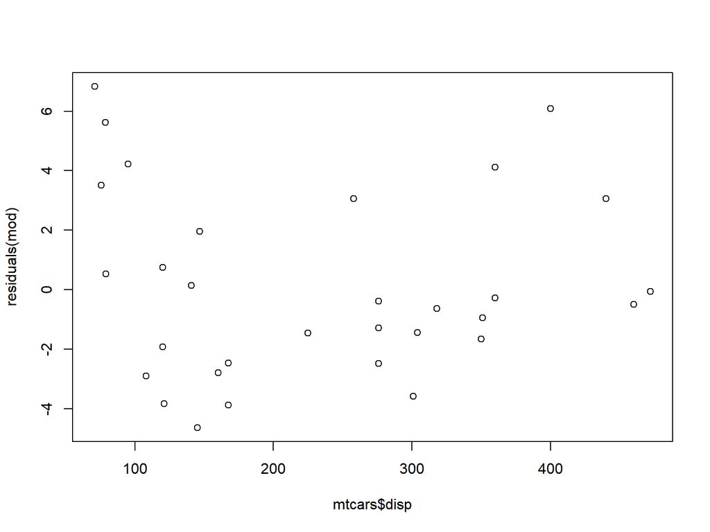

```r
mod <- lm(mpg ~ disp + am, mtcars)
plot(mtcars$disp, residuals(mod))
```

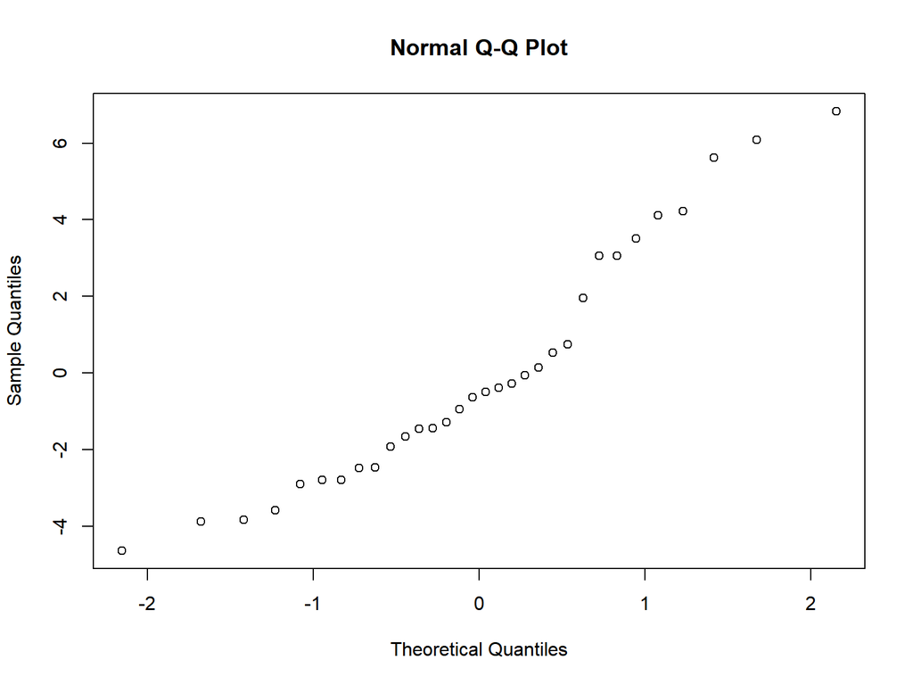

```r
qqnorm(residuals(mod))
```

# Reading your data into R

- Data can be read into R in a variety of formats
- Here we focus on tabular formats where data is stored in basic text files
- We also assume that each column is separated with a particular separator
- Examples include tab delimited files and comma separated files
- We can read in a file with comma separated values (csv) using

```r
platelet <- read.table("platelet.csv", sep = ",", header = T)
```

# File Access / Working Directory

- The working directory is the folder that you are working in
- When accessing files in working directory, you do not need to provide a file path
- `getwd()` tells you your current working directory
- If the file you want to access is not in the current working directory, you can change the working directory with `setwd()`

```r
setwd("C:/mystuff/")
```

- The backslash “\” is an escape character in R. If you use it for file paths, you must use it twice

```r
setwd("C:\\mystuff\\")
```

- Alternatively, you can use the dropdown for changing the working directory

# Exercise 6: Read data into R from the file `catpain.csv`

- Try reading in the file `catpain.csv`
- Look at the first few rows of the data with the `head` function

# Exercise 6: Solution

- Your solution will differ slightly from this

```r
setwd("./data")
catpain <- read.table("catpain.csv", header = T, sep = ",")
head(catpain)
```

# Pearson’s chi-squared: Vitamin C and the Common Cold

- Experiment to understand whether vitamin C helps to prevent the common cold
- 818 volunteers
- Vitamin C group received 1000mg of vitamin C per day
- Control group received equal amount of inert pill
- The data is shown below

```r
cc <- matrix(c(335, 302, 76, 105), nrow = 2)
colnames(cc) <- c("cold", "nocold")
rownames(cc) <- c("placebo", "vitaminc")
cc
```

```
##          cold nocold
## placebo   335     76
## vitaminc  302    105
```

- We conduct a chi-squared test to assess whether contracting the common cold is plausibly independent of taking vitamin C
- We use the function `chisq.test()` to conduct the test

```r
chisq.test(cc, correct = F)
```

```
##
##  Pearson's Chi-squared test
##
## data:  cc
## X-squared = 6.3366, df = 1, p-value = 0.01183
```

- We find moderate evidence against independence of taking vitamin C and contracting the common cold (X-squared = 6.33, p = 0.012).

# Exercise 7: Pearson’s chi-squared

- Investigation into association between smoking and lung cancer
- 86 lung cancer patients and 86 random individuals from the same community were interviewed about their smoking habits
- Conduct a chi-squared test to assess the plausibility of smoking and lung cancer being independent in these two groups of individuals

```r
cancer <- matrix(c(83, 3, 72, 14), nrow = 2)
colnames(cancer) <- c("cancer", "control")
rownames(cancer) <- c("smokers", "nonsmokers")
cancer
```

```
##            cancer control
## smokers        83      72
## nonsmokers      3      14
```

# Exercise 7: Solution

- We find convincing evidence against independence of smoking and lung cancer (X-squared = 7.90, p = 0.0049).

```r
chisq.test(cancer, correct = F)
```

```
##
##  Pearson's Chi-squared test
##
## data:  cancer
## X-squared = 7.8983, df = 1, p-value = 0.004948
```

# Logistic Regression

- Logistic regression is used for modeling binary data
- It extends the simple tests of odds for two groups to allow this test to be made after adjusting for other variables
- This can allow you to test for an effect after accounting for confounding factors
- Logistic regression involves interpretation of odds ratios

# Odds

- Odd is defined as the proportion yes divided by the proportion no
- $\omega_i = \pi / (1-\pi)$
- An event with a chance of 0.95 has odds of 19 to 1 in favor of its occurrence
- Odds must be greater than 0 with no upper limit
- Proportions must be between 0 and 1

# Titanic Dataset

- The Titanic dataset from the PASWR library gives information about the passangers on the Titanic, including whether they survived
- We can help understand more about what happened on the titanic by modeling survival with logistic regression
- The data can be found in the `PASWR` library
- Make sure to run `install.packages('PASWR')`

```r
library(PASWR)
head(titanic3)
```

```
##   pclass survived                            name    sex     age sibsp
## 1    1st        1   Allen, Miss. Elisabeth Walton female 29.0000     0
## 2    1st        1  Allison, Master. Hudson Trevor   male  0.9167     1
## 3    1st        0    Allison, Miss. Helen Loraine female  2.0000     1
## 4    1st        0 Allison, Mr. Hudson Joshua Crei   male 30.0000     1
## 5    1st        0 Allison, Mrs. Hudson J C (Bessi female 25.0000     1
## 6    1st        1             Anderson, Mr. Harry   male 48.0000     0
##   parch ticket     fare   cabin    embarked boat body
## 1     0  24160 211.3375      B5 Southampton    2   NA
## 2     2 113781 151.5500 C22 C26 Southampton   11   NA
## 3     2 113781 151.5500 C22 C26 Southampton        NA
## 4     2 113781 151.5500 C22 C26 Southampton       135
## 5     2 113781 151.5500 C22 C26 Southampton        NA
## 6     0  19952  26.5500     E12 Southampton    3   NA
##                         home.dest
## 1                    St Louis, MO
## 2 Montreal, PQ / Chesterville, ON
## 3 Montreal, PQ / Chesterville, ON
## 4 Montreal, PQ / Chesterville, ON
## 5 Montreal, PQ / Chesterville, ON
## 6                    New York, NY
```

- We are interested in understanding if the rates of survival substantially different for different passenger classes?
- A likelihood ratio test (chi-square = 127.8, p < 2.2e-16) provides substantial evidence against the null hypothesis of no differences in the survival rate between passanger classes

```r
mod <- glm(survived ~ pclass, data = titanic3, family = "binomial")
drop1(mod, test = "Chisq")
```

```
## Single term deletions
##
## Model:
## survived ~ pclass
##        Df Deviance    AIC    LRT  Pr(>Chi)
## <none>      1613.3 1619.3
## pclass  2   1741.0 1743.0 127.77 < 2.2e-16 ***
## ---
## Signif. codes:  0 '***' 0.001 '**' 0.01 '*' 0.05 '.' 0.1 ' ' 1
```

- We can determine the odds ratio of survival comparing 2nd class to 1st class

```r
summary(mod)
```

```
##
## Call:
## glm(formula = survived ~ pclass, family = "binomial", data = titanic3)
##
## Deviance Residuals:
##     Min       1Q   Median       3Q      Max
## -1.3896  -0.7678  -0.7678   0.9791   1.6525
##
## Coefficients:
##             Estimate Std. Error z value Pr(>|z|)
## (Intercept)   0.4861     0.1146   4.242 2.21e-05 ***
## pclass2nd    -0.7696     0.1669  -4.611 4.02e-06 ***
## pclass3rd    -1.5567     0.1433 -10.860  < 2e-16 ***
## ---
## Signif. codes:  0 '***' 0.001 '**' 0.01 '*' 0.05 '.' 0.1 ' ' 1
##
## (Dispersion parameter for binomial family taken to be 1)
##
##     Null deviance: 1741.0  on 1308  degrees of freedom
## Residual deviance: 1613.3  on 1306  degrees of freedom
## AIC: 1619.3
##
## Number of Fisher Scoring iterations: 4
```

- The value -0.77 represents the log odds of survival for 2nd class vs. first class
- We can compute the odds ratio by reversing the transformation using exp

```r
exp(-0.77)
```

```
## [1] 0.4630131
```

- Confidence intervals can be obtained using confint
- We can compute confidence intervals on the odds ratios by reversing the transformation again

```r
exp(confint(mod))
```

```
##                 2.5 %    97.5 %
## (Intercept) 1.3012373 2.0400409
## pclass2nd   0.3333370 0.6415244
## pclass3rd   0.1588234 0.2786634
```

- A 95% confidence interval on the odds ratio ranges from 0.33 to 0.64

# Exercise 8: Logistic regression

- Regress survival on gender only
- Estimate and produce 95% confidence intervals on the odds of survival for females to males

# Exercise 8: Solution

```r
mod <- glm(survived ~ sex, data = titanic3, family = "binomial")
exp(2.42)
```

```
## [1] 11.24586
```

```r
exp(-confint(mod))
```

```
##                  2.5 %    97.5 %
## (Intercept)  0.4580056 0.3045032
## sexmale     14.8093675 8.6871038
```

# Random Effects

When you might consider using a random effect

- don’t want to test hypotheses about differences between responses at particular levels of the grouping variable
- do want to quantify the variability among levels of the grouping variable
- do want to make predictions about unobserved levels of the grouping variable
- do want to combine information across levels of the grouping variable
- have variation in information per level (number of samples or noisiness)
- have levels that are randomly sampled from/representative of a larger population
- have a categorical predictor that is a nuisance variable (is not of direct interest but should be controlled for)

If you have sampled fewer than five levels of the grouping variable, you should strongly consider treating it as a fixed effect even if one or more criteria above apply

Bolker, Benjamin M. “Linear and Generalized Linear Mixed Models.” In Ecological Statistics, edited by Gordon A. Fox, Simoneta Negrete-Yankelevich, and Vinicio J. Sosa, 309–33. Oxford University Press, 2015. https://doi.org/10.1093/acprof:oso/9780199672547.003.0014.

# Random Effects Models in R

- Here we fit a random effects model using the `lmer` function
- We can add a random effect for Rail using `(1|Rail)`
- The summary command shows us the estimates of the variation due to between Rails and variation due to within Rails

```r
library(nlme)
library(lme4)
mod <- lmer(travel ~ (1|Rail), data = Rail)
summary(mod)
```

```
## Linear mixed model fit by REML ['lmerMod']
## Formula: travel ~ (1 | Rail)
##    Data: Rail
##
## REML criterion at convergence: 122.2
##
## Scaled residuals:
##      Min       1Q   Median       3Q      Max
## -1.61883 -0.28218  0.03569  0.21956  1.61438
##
## Random effects:
##  Groups   Name        Variance Std.Dev.
##  Rail     (Intercept) 615.31   24.805
##  Residual              16.17    4.021
## Number of obs: 18, groups:  Rail, 6
##
## Fixed effects:
##             Estimate Std. Error t value
## (Intercept)    66.50      10.17   6.538
```

# Other R Resources

- Learn about the key tidyverse packages
  - https://dplyr.tidyverse.org/
  - https://ggplot2.tidyverse.org/
  - https://tidyr.tidyverse.org/
- See `multcomp` package for doing multiple comparisons
- Some handy cheatsheets
  - https://www.rstudio.com/resources/cheatsheets/
- Get your R questions answered
  - https://stackoverflow.com/questions/tagged/r
- Get your stats questions answered
  - https://stats.stackexchange.com/
- Get your quantitative methods for medicine questions answered
  - https://discourse.datamethods.org/about
- Ask questions about mixed effects models
  - https://stat.ethz.ch/mailman/listinfo/r-sig-mixed-models